# Interview Tasks

Gabriel Mutua

25th December,2018

## **Introduction**

You have been provided with data on mortality in Kenya. This data can be useful in informing products for life insurance products. There are several analysis that can be conducted to enable make better decisions for creating and marketing of life insurance products. These analyses will form part of your interview.

### *Task 1*

Create a Kaplan-meier survival curve using one of the following variables; gender, colour, fundraising, spouse alive, spouse gender. Explain the difference/significance of the result.

#### *Answer*

##### *Step 1 Data Preparation*

I started by doing data preparation in Python. I was interested to know out of the given variables that is (gender, colour, fundraising, spouse alive, spouse gender) which one would affect mortality rate of an individual. I started by investigating *** Gender variable *** and it’s impact on mortality.

I performed the following data preparations tasks.

1. Loading the dataset.
2. Getting variables of interest Age and Gender.
3. Removing nan value from the newly created dataframe.
4. Creating new column Gender_Status which binary (1 if spouse is Male and 0 when Female ).
5. Write data again back to a .csv file.
6. Checking basic stats.

```python
import pandas as pd
#1) Load dataset
all_data = pd.read_csv(r"C:\Users\Gabriel Mutua\Documents\GabuTheGreat.github.io\challange\Obituaries_Dataset.csv", encoding = "ISO-8859-1")
#2) Get variables of interest Age and Gender
all_data = all_data[['Age','Gender']]
#3) Remove nan value from the newly created dataframe
all_data = all_data.dropna(how='any',axis=0)
#4) Create new column Gender_Status which binary (1 if spouse is alive and 0 when not )
def gender_status(x):
    if "Male" in x:
        return 1
    elif "Female" in x:
        return 0
    else: return "nan"

all_data['Gender_Status'] = all_data['Gender'].apply(gender_status)
#5) Write data again back to a .csv file
#all_data.to_csv(r"C:\Users\Gabriel #Mutua\Documents\GabuTheGreat.github.io\challange\survival_gender.csv", #sep=',', encoding='utf-8', index=False)
print(all_data.head(10))
#view the first 10 rows
```

```
##     Age  Gender  Gender_Status
## 0  66.0    Male              1
## 1  43.0  Female              0
## 2  35.0    Male              1
## 3  54.0    Male              1
## 4  41.0  Female              0
## 5  92.0  Female              0
## 6  79.0  Female              0
## 7  86.0    Male              1
## 8  72.0    Male              1
## 9  87.0  Female              0
```

```python
print(all_data.describe()['Age'])
#View overall stats for age.
```

```
## count    507.000000
## mean      65.422091
## std       20.492632
## min        1.000000
## 25%       51.000000
## 50%       68.000000
## 75%       81.500000
## max      117.000000
## Name: Age, dtype: float64
```

```python
print(all_data.groupby("Gender").mean())
#View overall stats grouped by Gender
```

```
##               Age  Gender_Status
## Gender
## Female  67.929825              0
## Male    63.372760              1
```

##### *Step 2 Creating a Kaplan-meier survival curve*

First I calculated the Kaplan-Meier estimate in R using survfit() function from survival package. I checked the summary of the calculated value. Then plotted the Kaplan-meier survival curve.

```r
#load required library
library("survival")

#Load processed data
survival_data <- read.csv("survival_gender.csv", header = TRUE)

#Calculating the Kaplan-Meier estimate
KM_fit <- survfit(Surv(Age, Gender_Status) ~ 1, data = survival_data)

#Print calculated value
print(KM_fit)
```

```
## Call: survfit(formula = Surv(Age, Gender_Status) ~ 1, data = survival_data)
##
##       n  events  median 0.95LCL 0.95UCL
##     507     279      77      76      82
```

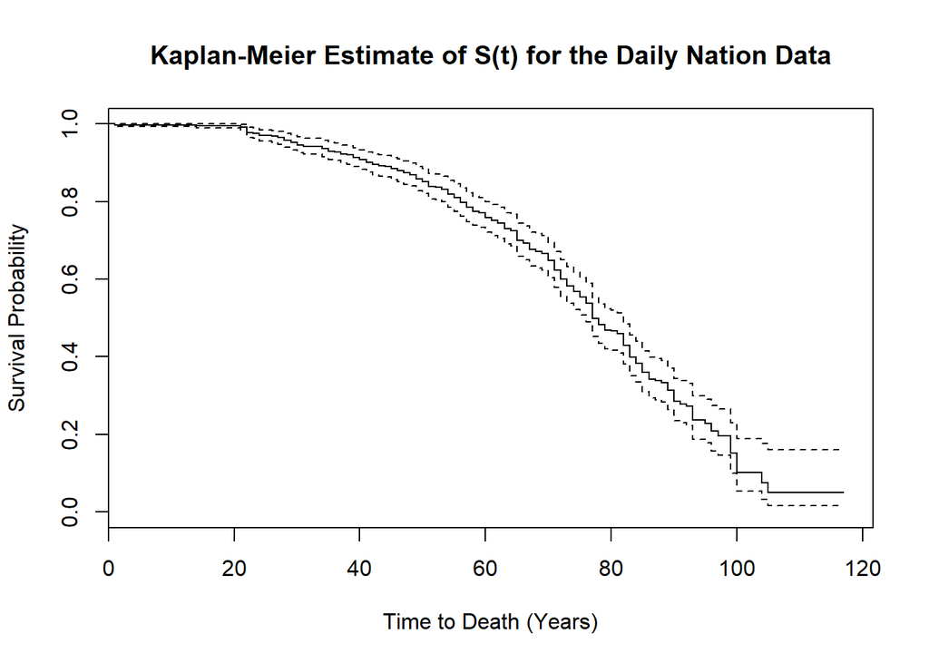

```r
plot(KM_fit, xlab = "Time to Death (Years)", ylab = "Survival Probability",
     main = "Kaplan-Meier Estimate of S(t) for the Daily Nation Data")
```

*Explain the difference/significance of the result.*

According to the provided data set, it’s clear that as age advances the survival probability drastically reduces.

### *Task 2*

#### *Answer*

##### *Step 1 Data Preparation*

I started the process of data preparation in Python. I performed the following procedures on the data set.

1. Getting the data type of all columns. So that I can establish columns to use in my analysis.
2. Creating a new dataframe with variables to be used in the prediction.
3. Creating a new fundraising status column. If fundraising is yes fundraising status = 1, if no = 0.
4. Removing all nan value in the data frame

```python
import pandas as pd
all_data = pd.read_csv(r"C:\Users\Gabriel Mutua\Documents\GabuTheGreat.github.io\challange\Obituaries_Dataset.csv", encoding = "ISO-8859-1")
#1) Getting data types of all columns
all_data.dtypes
#2) Taking the varibles to be used in the model.
all_data_machine = all_data[['Fundraising','Age','No_of_Children','No_of_Relatives']]
#Drop all nan
all_data_machine = all_data_machine.dropna(how='any',axis=0)
#3) Function to create new binary column 1 = Fundraising = Yes 0, fundraising = 0
def fund_status(x):
    if "Yes" in x:
        return 1
    elif "No" in x:
        return 0
    else: return "nan"

all_data_machine['Fundraising_Status'] = all_data_machine['Fundraising'].apply(fund_status)
#Re-arranging the columns
all_data_machine = all_data_machine[['Age','No_of_Children','No_of_Relatives','Fundraising','Fundraising_Status']]
#Convert the data type of 'No_of_Relatives'
all_data_machine['No_of_Relatives'] = pd.to_numeric(all_data_machine['No_of_Relatives'],errors='coerce')
#4)Remove nan value from the newly created dataframe
all_data_machine = all_data_machine.dropna(how='any',axis=0)
#print the shape of the data frame
print(all_data_machine.shape)
```

```
## (439, 5)
```

##### *Step 2 Splitting the data.*

I setttled for a logistic regression, which is extension of linear regression where the dependent variable is categorical and not continuous. I fitted the model using R.

```r
#Reading data into R
task2_data = read.csv("survival_data.csv", header = TRUE)

#Analysing quality of the data set
str(task2_data)
```

```
## 'data.frame':    439 obs. of  5 variables:
##  $ Age               : num  66 43 35 54 92 79 86 72 87 90 ...
##  $ No_of_Children    : num  7 4 4 4 4 11 7 3 19 11 ...
##  $ No_of_Relatives   : num  35 8 7 33 19 115 2 24 26 0 ...
##  $ Fundraising       : Factor w/ 2 levels "No","Yes": 2 2 1 1 1 1 1 1 2 1 ...
##  $ Fundraising_Status: int  1 1 0 0 0 0 0 0 1 0 ...
```

We have 439 observations, one for each of the deaths in our data set, and 5 different variables. The 3 variables from Ages to No_of_Relatives are the independent variables while Fundraising_Status is the dependent/outcome variable.

Since we have only one data set, we want to randomly split our data set into a training set and testing set. Testing set is essential to validate our results.

```r
#Using CaTools to randomly divide the data into Training and Test set
library(caTools)
set.seed(67)
split = sample.split(task2_data$Fundraising_Status, SplitRatio = 0.75)

task2_Train = subset(task2_data, split == TRUE)
task2_Test = subset(task2_data, split == FALSE)

#Dimensions of task2_Train
print(dim(task2_Train))
```

```
## [1] 329   5
```

```r
#Dimensions of task2_Test
print(dim(task2_Test))
```

```
## [1] 110   5
```

##### *Step 3 Fitting logistic model*

Now, we are ready to build a logistic regression model using Age,No_of_Relatives and No_of_Children as independent variables.We’ll call our model glm.fit and use the “glm” function.

```r
#fitting the model
glm.fit = glm(Fundraising_Status ~  Age + No_of_Children + No_of_Relatives,data=task2_Train, family=binomial)
#check the model summary
print(summary(glm.fit))
```

```
##
## Call:
## glm(formula = Fundraising_Status ~ Age + No_of_Children + No_of_Relatives,
##     family = binomial, data = task2_Train)
##
## Deviance Residuals:
##     Min       1Q   Median       3Q      Max
## -1.5408  -1.3665   0.9321   0.9812   1.0750
##
## Coefficients:
##                  Estimate Std. Error z value Pr(>|z|)
## (Intercept)      0.886626   0.423785   2.092   0.0364 *
## Age             -0.007438   0.007468  -0.996   0.3193
## No_of_Children   0.009275   0.032463   0.286   0.7751
## No_of_Relatives  0.002502   0.005599   0.447   0.6549
## ---
## Signif. codes:  0 '***' 0.001 '**' 0.01 '*' 0.05 '.' 0.1 ' ' 1
##
## (Dispersion parameter for binomial family taken to be 1)
##
##     Null deviance: 435.94  on 328  degrees of freedom
## Residual deviance: 434.58  on 325  degrees of freedom
## AIC: 442.58
##
## Number of Fisher Scoring iterations: 4
```

##### *Step 4 Making predictions on Training set*

```r
glm.probs <- predict(glm.fit,type = "response")

#I'll turn the probabilities into classifications by thresholding at 0.6.
#In order to do so, I use an ifelse() command
glm.pred <- ifelse(glm.probs > 0.6, 0, 1)

#Create confusion Matrix
attach(task2_Train)
print(table(glm.pred,Fundraising_Status))
```

```
##         Fundraising_Status
## glm.pred   0   1
##        0  93 161
##        1  31  44
```

```r
#Check the overall accuracy in percentage
print((mean(glm.pred == Fundraising_Status))*100)
```

```
## [1] 41.64134
```

```r
# Sensitivity
print((44/(31+44))*100)
```

```
## [1] 58.66667
```

```r
# Specificity
print((93/(93 + 161))*100)
```

```
## [1] 36.61417
```

After testing with several threshholds, I saw that by increasing the threshold value, the model’s sensitivity decreases and specificity increases while the reverse happens if the threshold value is decreased.

##### *Step 5 Choosing optimum threshold value*

```r
predictTrain = predict(glm.fit, type="response")

library(ROCR)
```

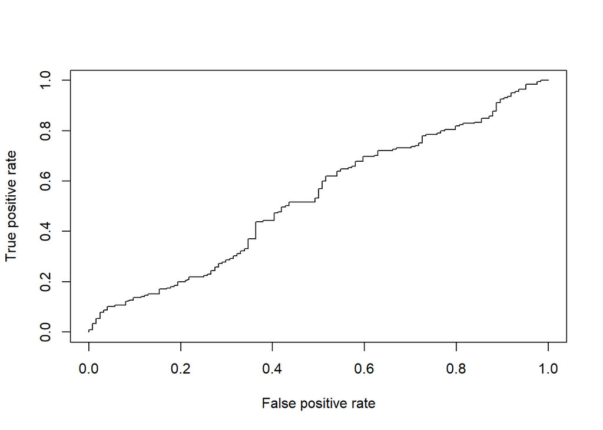

```r
ROCRpred = prediction(predictTrain, task2_Train$Fundraising_Status)
ROCRperf = performance(ROCRpred, "tpr", "fpr")
plot(ROCRperf)
```

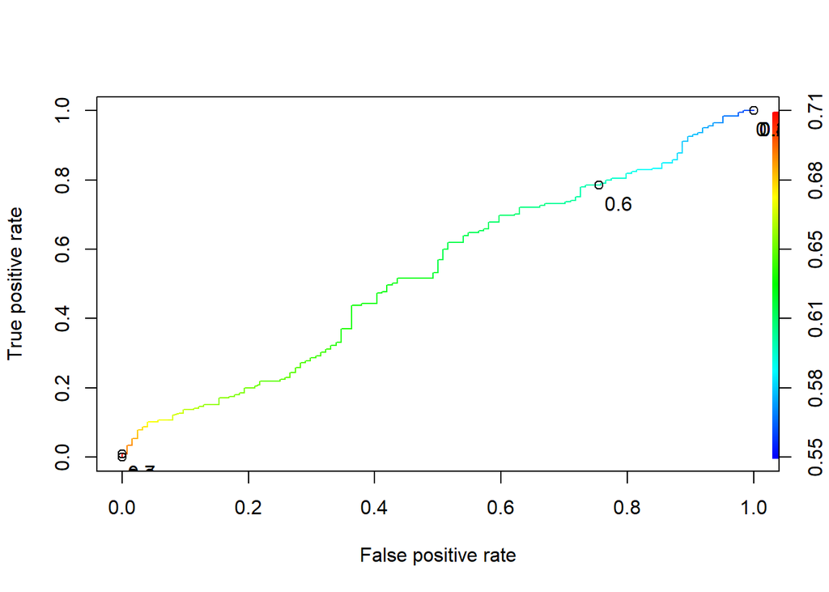

```r
plot(ROCRperf, colorize=TRUE)
plot(ROCRperf, colorize=TRUE, print.cutoffs.at=seq(0,1,by=0.1), text.adj=c(-0.2,1.7))
```

The sensitivity, or true positive rate of the model, is shown on the y-axis.while the false positive rate, or 1 minus the specificity, is given on the x-axis. The line shows how these two outcome measures vary with different threshold values.

A threshold around (0.6, 0.65) on this ROC curve looks like a good choice in this case.

##### *Step 6 Prediction on Test Set*

```r
glm.probs <- predict(glm.fit,type = "response",newdata = task2_Test)
glm.pred <- ifelse(glm.probs > 0.65, 0, 1)
attach(task2_Test)
table(glm.pred,Fundraising_Status)
```

```
##         Fundraising_Status
## glm.pred  0  1
##        0  7 18
##        1 35 50
```

```r
#Check the overall accuracy in percentage
print(mean(glm.pred == Fundraising_Status)*100)
```

```
## [1] 51.81818
```

```r
# Sensitivity
print((50/(35+50))*100)
```

```
## [1] 58.82353
```

```r
# Specificity
print((7/(7 + 18))*100)
```

```
## [1] 28
```